# (Ford Go Bike 2017 Data Visualization)

## by (Mourad Elzeiny)

### Imagine yourself riding a bike and enjoying the breathtaking views of San Francisco, enjoing the sea views and many more wonderfull views...... oh what a great moments.!...... But stop the imagination for a while ...you need firstly to know more about the best stations , avoiding rush hours , and best time for your ride......so lets take a tour and visualizing some data in order to enjoy your ride.....

## Introduction

> In June 2017 the system was officially re-launched as Ford GoBike in a partnership with Ford Motor Company.

> The bicycles are available 24 hours a day, seven days a week for periods ranging from a single ride (up to 30 minutes) to a day pass, in 30-minute increments, or customers can purchase an annual subscription which gives them unlimited rides up to 45-minutes in duration

> for more information:(https://en.wikipedia.org/wiki/Bay_Wheels)

> Data source:(https://www.lyft.com/bikes/bay-wheels/system-data)

## Univariate Exploration

> In this section, we explore the data and detect is there any data which need to be cleaned , and also explore the data as each variable and count of frequencies inside it

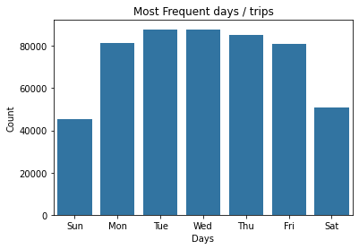

```python
#finding the most
week_days = ['Sun', 'Mon', 'Tue', 'Wed', 'Thu', 'Fri', 'Sat']
base_color = sb.color_palette()[0]
sb.countplot(data=df_ford, x = 'start_week', color = base_color, order = week_days);
plt.xlabel('Days');
plt.ylabel('Count');
plt.title('Most Frequent days / trips');
```

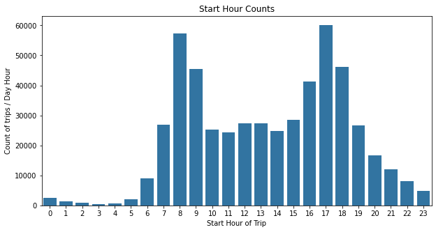

```python
plt.figure(figsize = [10,5])
sb.countplot(data=df_ford, x='start_hour', color=base_color);
plt.xlabel('Start Hour of Trip');
plt.ylabel('Count of trips / Day Hour');
plt.title('Start Hour Counts');
```

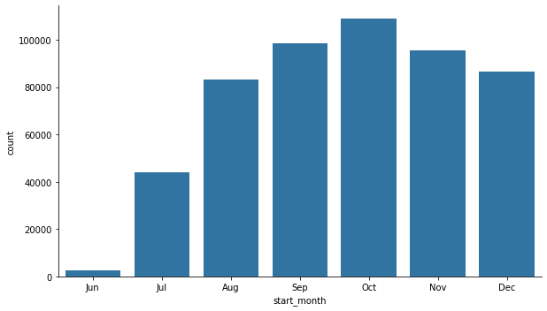

```python
months = [ 'Jun', 'Jul', 'Aug', 'Sep', 'Oct', 'Nov', 'Dec']
sb.catplot(data = df_ford, x = 'start_month', kind = 'count', color = base_color,order = months,  aspect = 1.7);
```

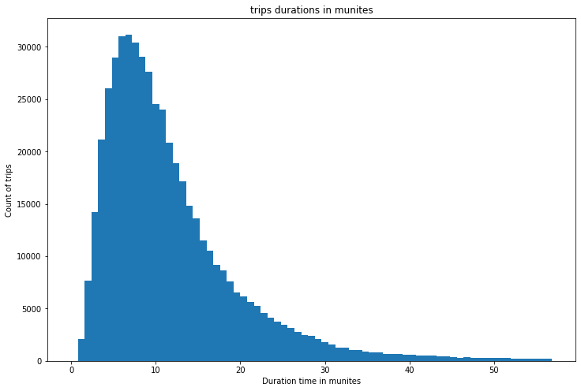

```python
# we can use standard deviation as the maxumium for x bar
binsize = 0.8
bins = np.arange(0, 57, binsize)

plt.figure(figsize=[12, 8])
plt.hist(data = df_ford, x = 'duration_min', bins = bins)
plt.xlabel('Duration time in munites');
plt.ylabel('Count of trips');
plt.title('trips durations in munites');
```

## Bivariate Exploration

> In this section, we will investigate relationships between pairs of variables to detect is any variable affects the other

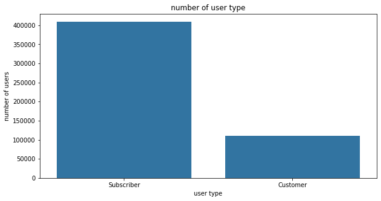

```python
# know the majority of usertype is there are customers or subscribers

plt.figure(figsize = [10, 5])

sb.countplot(data = df_ford, x = "user_type", order = df_ford.user_type.value_counts().index, color = base_color);
plt.xlabel('user type');
plt.ylabel('number of users');
plt.title('number of user type');
```

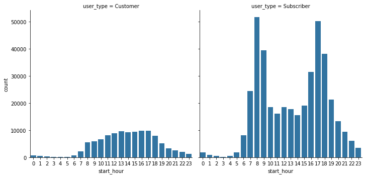

```python
# comparing the rush hours for each group
# Customer Usage by Month vs. Subscriber Usage by Month

sb.catplot(data=df_ford, x='start_hour', col="user_type", kind='count', sharey = True,color = base_color );
```

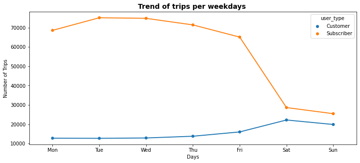

```python
plt.figure(figsize=(12, 5))

df_ford_wdays = df_ford.groupby(['start_week', 'user_type']).size().reset_index()
weekday = ['Mon', 'Tue', 'Wed', 'Thu', 'Fri', 'Sat', 'Sun']

sb.pointplot(data=df_ford_wdays, x='start_week', y=0, hue = 'user_type', scale=.7, order = weekday);

plt.title('Trend of trips per weekdays ', y=1, fontsize=14, fontweight='bold')
plt.xlabel('Days')
plt.ylabel('Number of Trips');
```

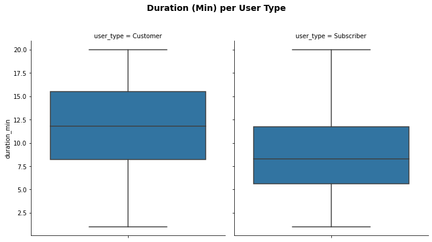

```python
# comparing the duration of the trips fro customers and subscribers

# As most of our data (75%) on our duration column is under 16 min , we will query the data to under 20 min

data = df_ford.query('duration_min < 20')
f = sb.catplot(data=data, y='duration_min', col="user_type", kind='box')
f.fig.suptitle('Duration (Min) per User Type', y=1.1, fontsize=14, fontweight='bold');
```

## Multivariate Exploration

> In this section we will go further showing more relations between variables

[figure not shown]

```python
# average trip duration etween customers and subscribers on weekdays

sb.pointplot(data= df_ford, x='start_week', y='duration_min', hue='user_type', dodge=0.3, linestyles="");
plt.xlabel('Days');
plt.ylabel('Avg. Trip Duration in Minute');
```

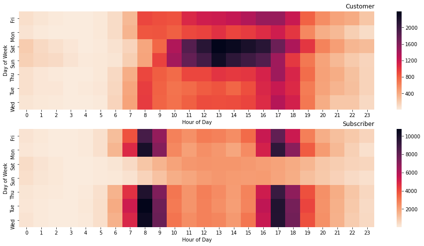

```python
plt.suptitle('Hourly Usage during Weekdays for Customers and Subscribers')
#fig, ax = plt.subplots(figsize=(5,5))

plt.figure(figsize = (16,8))
plt.subplot(2, 1, 1)
customers = df_ford.query('user_type == "Customer"')
ct_counts = customers.groupby(['start_week', 'start_hour']).size()
ct_counts = ct_counts.reset_index(name='count')
ct_counts = ct_counts.pivot(index='start_week', columns='start_hour', values='count')
sb.heatmap(ct_counts, cmap='rocket_r');
plt.title('Customer', loc='right');
plt.xlabel('Hour of Day');
plt.ylabel('Day of Week');

plt.subplot(2, 1, 2)
subscribers = df_ford.query('user_type == "Subscriber"')
st_counts = subscribers.groupby(['start_week', 'start_hour']).size()
st_counts = st_counts.reset_index(name='count')
st_counts = st_counts.pivot(index='start_week', columns='start_hour', values='count')
sb.heatmap(st_counts, cmap='rocket_r');
plt.title('Subscriber', loc='right');
plt.xlabel('Hour of Day');
plt.ylabel('Day of Week');
```